# Overlapping: an application of permutation test to the Overlapping Index

A. Perugini, G. Calignano, M. Nucci, L. Finos, M. Pastore

Pychoco Workshop 5 - 6 February 2026 | Padova

## The Overlapping Index

The overlapping ($\eta$) is an index of effect size and varies from 0 and 1, formally defined in the following way:

$$\begin{eqnarray}
\eta (A,B) = \int_{\mathbb{R}^n} min [f_A (x),f_B (x)] dx
\end{eqnarray}$$

$\eta (A,B)$ is normalized to one and when the distributions of A and B do not have points in common, meaning that $f_A (x)$ and $f_B (x)$ are disjoint, $\eta (A,B) = 0$

## Hypothesis testing

- Usually $H_0$ is defined as the absence of an effect.
- $\eta = 1$ means complete overlap
- We define the complement $\zeta$ as $1 - \eta$ and define $H_0 : \zeta = 0$ meaning that there is no difference between the densities of the two populations.

## Permutation test

- Rearranges the data $B$ times
- Calculates the statistic for each new dataset of permuted data
- Calculates $p$-value as the probability of obtaining equal or more extreme values

$$\begin{eqnarray}
p=\frac{(\sum_{b=1}^B |t_b|\geq |t|)+1}{B+1}
\end{eqnarray}$$

where $B$ is the number of random permutations, $t$ is the $t$-statistic computed on the observed data, $t_b$ are those computed on the permuted data.

## Applied to the Overlapping

The permutation test is applied to $\zeta$:

$$\begin{eqnarray*}
p = \frac{(\# \hat{\zeta}_b \geq \hat{\zeta})+1 }{B+1}
\end{eqnarray*}$$

The principle is the same, we shuffle the data and calculate $\zeta$ B times to calculate the $p$-value.

## Example on Reaction Time

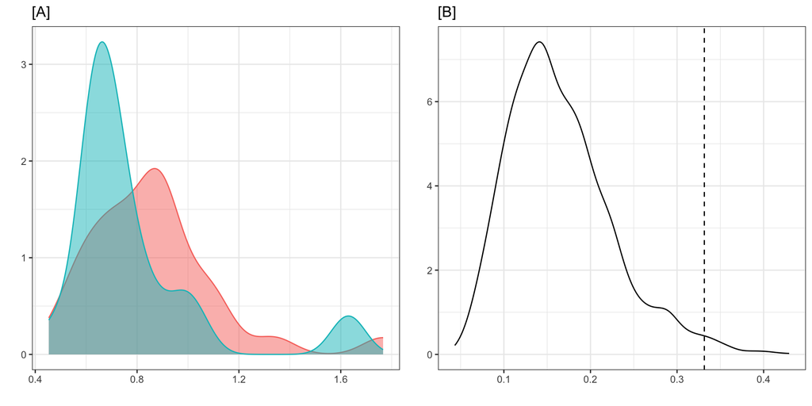

Panel [A] shows the two conditions with $\eta = .67$ and $\zeta = .33$, panel [B] shows the distribution of the $\zeta$ statistic obtained through permutation ($p = .011$)

## The simulation study

We simulated from the Skew-Normal distribution.

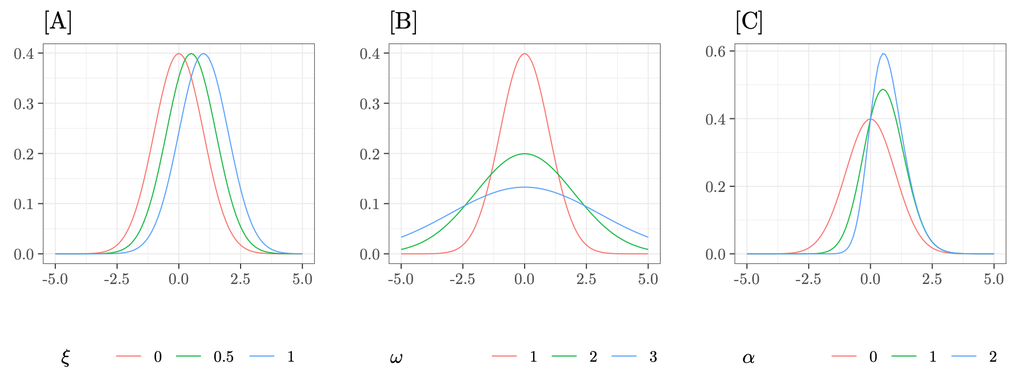

## Statistical tests for comparison

For each combination $\delta$ $\times$ $\sigma$ $\times$ $\alpha$ $\times$ $n$, on the generated data were performed the following tests:

- **Permutation test** on the complement of the **Overlapping Index** ($\zeta_{ov}$), $\zeta = 1-\eta$;
- **$F$ test** (F) of homogeneity of variances;
- **Kolmogorov-Smirnov test** (ks) comparing the cumulative distributions.
- **Wilcoxon-Mann-Whitney test** (wmw) on ranks;
- **Welch test** (w) assuming normality but not homogeneity of variance;
- **$t$ test** (t) for independent samples, assuming equal variance and normality;

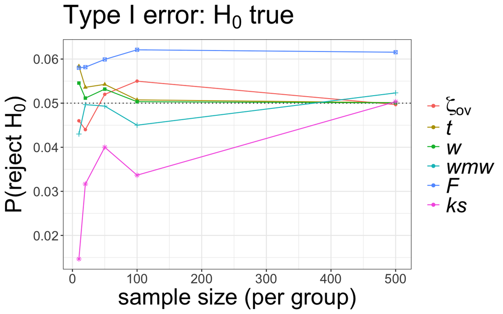

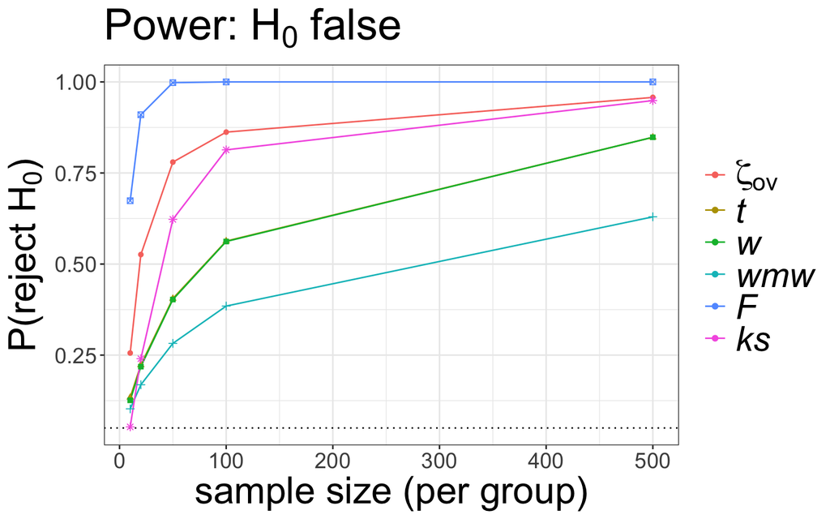

## Discussion

- The $\zeta$ overlapping test outperforms in terms of power other tests, except for the F test, which does not control well for type I error.
- As a non-parametric test, it allows to make inference on the entire distribution without making any assumptions.
- It is an intuitive index and it allows to investigate group differences beyond the mean.

## To find out more:

Here you can find our pre-print, on the implementation of the permutation test for the overlapping index:

https://osf.io/preprints/osf/8h4fe_v1

[figure not shown]

[figure not shown]

ambra.perugini@phd.unipd.it